# Ziel

Wir wollen mit realen Daten spielen, sie erkunden und ein paar einfache Vorhersagen machen.

# Daten

Bike Share Toronto (https://bikesharetoronto.com/) ~630 Stationen und ~7000 Rädern

Die Datenfelder sind

- Trip ID [int]
- Trip Duration [s, int]
- Trip Start Station ID [int]
- Trip Start time [timestamp]
- Trip Start Station Name [string]
- Trip End Station ID [int]
- Trip End Time [timestamp]
- Trip End Station Name [string]
- Bike ID [int]
- User type [string, eigentlich boolean 0/1 (member/casual)]

# Lineare Regression

Wir verwenden einen Mini-Datensatz der 1960 von Nancy Howell zum Studium des Volkes der ǃKung gesammelt wurde (https://en.wikipedia.org/wiki/%C7%83Kung_people)

```python
df = pd.read_csv("../data/Howell1_young.csv")
```

```python
df.head()
```

|  | Unnamed: 0 | height | weight | age | male |
| --- | --- | --- | --- | --- | --- |
| 0 | 8 | 147.955 | 34.869885 | 19.0 | 0 |
| 1 | 13 | 149.900 | 47.700000 | 20.0 | 0 |
| 2 | 18 | 121.920 | 19.617854 | 12.0 | 1 |
| 3 | 19 | 105.410 | 13.947954 | 8.0 | 0 |
| 4 | 20 | 86.360 | 10.489315 | 6.5 | 0 |

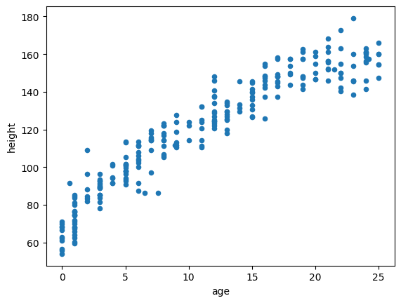

```python
df.plot.scatter(x="age", y="height")
```

Modell: $y =f(x)$ mit $f$ unbekannt und *linear*.

$y = a\cdot x + b$

wähle $a,b$ so, dass $f$ "gut" zu den Daten passt $\to$ die mittlere quadratische Abweichung zwischen f und den Datenpunkten ist minimal.

Gegeben n Paare von Datenpunkten $(x^{(1)}, y^{(1)}), ..., (x^{(n)}, y^{(n)})$ suchen wir $a,b$ so dass der Ausdruck

$\frac{1}{n} \sum_{i=1}^n (a\cdot x^{(i)} + b - y^{(i)})^2$

minimal wird.

```python
linear_reg = sklearn.linear_model.LinearRegression()
x = df[["age"]]
y_true = df["height"]
linear_reg.fit(x,y_true)
```

```
LinearRegression()
```

```python
a = linear_reg.coef_[0]
b = linear_reg.intercept_
print(f"a = {a}, b = {b}")
```

```
a = 3.6991808845422742, b = 78.39875682737627
```

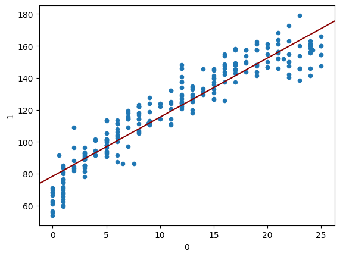

```python
ax = pd.DataFrame(list(zip(x.iloc[:,0],y_true))).plot.scatter(x=0, y=1)
y_pred = linear_reg.predict(x)
ax.axline((0,b), slope=a, color="darkred")
```

# Over/Underfitting

# Aufgabe

1. Mache Dich mit den Daten vertraut (download, Einlesen)
2. Hauptaufgabe: Für jeden Tag und Station voraussagen, wie viele Fahrräder dort ausgeliehen werden.
3. Nebenaufgaben (erstmal ein Modell für Frage 2 bauen und evaluieren!):
- Was könnten andere Maßzahlen als "tägliche Anzahl Ausleihvorgänge" sein, die vielleicht hilfreich(er) sind?
- Welchen Einfluss hatte Covid-19 auf das Ausleihverhalten?
- Graphische Darstellung auf der Karte von Toronto

# Evaluation

Wir wollen 1 Woche im Voraus vorhersagen, wie viele Räder an einem gewissen Tag an einer Station ausgeliehen werden.